# GBM Demo Notebook

##### Zhang Yi synapse@pku.edu.cn

##### 20220308

#### Introduction

In this vignette we show EpiTrace age application to scATAC of a cancer sample. Data is from NCBI GEO `GSE139136`.

**Reference**  
Guilhamon P, Chesnelong C, Kushida MM, Nikolic A et al. Single-cell chromatin accessibility profiling of glioblastoma identifies an invasive cancer stem cell population associated with lower survival. Elife 2021 Jan 11;10. PMID: 33427645  
Nikolic A, Singhal D, Ellestad K, Johnston M et al. Copy-scAT: Deconvoluting single-cell chromatin accessibility of genetic subclones in cancer. Sci Adv 2021 Oct 15;7(42):eabg6045. PMID: 34644115

#### Data loading

First we load the data via:

```r
library(dplyr)
library(tidyr)
library(readr)
library(GenomicRanges)
library(reshape2)
library(openxlsx)
library(ggplot2)
library(Matrix)
library(EpiTrace)
library(Seurat)
library(SeuratObject)
library(ggtree)
library(EnsDb.Hsapiens.v86)
library(patchwork)
library(ArchR)

data("clock_gr_list")
load('/Users/wing/Desktop/Eulerian/文件/内部研发项目/CLOCK_CANCER/Clock_Evolution/data/scGBM/GBM_GSM4131779.testdata.RData') # this is hg38
```

We have already processed the data into MatrixMarket format.

#### Creating the EpiTrace object

We prepare the peak-set and count matrix using `Init_Peakset` and `Init_Matrix`.

```r
GBM_GSM4131779$GR -> peakset
initiated_peaks <- Init_Peakset(peakset)
initiated_mm <- Init_Matrix(cellname = colnames(GBM_GSM4131779$MM),peakname = gsub('_','-',rownames(GBM_GSM4131779$MM)),matrix = GBM_GSM4131779$MM)
epitrace_obj <- EpiTrace_prepare_object(initiated_peaks,initiated_mm,ref_genome = 'hg38',non_standard_clock = F,clock_gr_list = clock_gr_list,qualnum=1)
```

```
ref clock list is set to be standard (Homo sapiens, hg19)
Input peakset is set to be hg38
```

```
[1] 0
```

```
add ChronologyClock
good quality cells 890 and peaks 5302
```

```
[1] 0
```

```
add AllClock
good quality cells 890 and peaks 5316
```

```
[1] 0
```

```
Performing TF-IDF normalization
Running SVD
Scaling cell embeddings
```

```r
DefaultAssay(epitrace_obj) <- 'peaks'
```

#### Basic pre-processing

The object could be re-clustered and re-analyzed. Here, we re-cluster it to a higher resolution, and try to remove some low-quality cells which tend to scatter across the UMAP space.

```r
epitrace_obj <- epitrace_obj %>% RunTFIDF() %>% FindTopFeatures(min.cutoff=50) %>% RunSVD() %>% RunUMAP(reduction = 'lsi', dims = 2:31) %>% FindNeighbors(reduction = 'lsi', dims = 2:31,k.param = 21) %>% FindClusters(verbose = FALSE, algorithm = 3,resolution = 0.8)
```

```
Performing TF-IDF normalization
Running SVD
Scaling cell embeddings
```

```r
epitrace_obj_backup <- epitrace_obj
epitrace_obj <- subset(epitrace_obj,seurat_clusters %ni% c('2','8'))
```

#### Estimate age and phylogeny

We estimate the EpiTrace age, and phylogeny based on EpiTrace age, by using the `RunEpiTraceAge` and `RunEpiTracePhylogeny` commands.

```r
epitrace_obj_age_estimated <- RunEpiTraceAge(epitrace_obj)
phylotree_res <- RunEpiTracePhylogeny(epitrace_obj_age_estimated,run_reduction = T)
```

```
Performing TF-IDF normalization
Running SVD
failed for MitosisClock
Performing TF-IDF normalization
Running SVD
Scaling cell embeddings
Performing TF-IDF normalization
Running SVD
Scaling cell embeddings
```

#### Add annotation for gene expression

Gene expression could usually be pulled out by Signac. However, the data we downloaded did not provide with a `fragments` file so we used peaks overlapping given gene instead. This is approximate, though imperfect, for visulization. However the result is visually similar to publication. Here we tested MDM4, EGFR and PDGFRA, which are known to be amplified in the sample.

```r
annotations <- GetGRangesFromEnsDb(ensdb = EnsDb.Hsapiens.v86)
seqlevelsStyle(annotations) <- 'UCSC'
genome(annotations) <- "hg38"

target_genes <- c('MDM4','EGFR','PDGFRA')
granges(epitrace_obj_age_estimated) -> tempdf_GR
lapply(target_genes,function(x){
  if(x %in% 'PDGFRA'){
    widthid = 10000
  }else{
    widthid = 300
  }
  tempdf_GR[findOverlaps(tempdf_GR,flank(annotations[annotations$gene_name %in% x,],width=widthid,both=T))@from %>% unique,] -> testdf
  testdf$gene <- x
  testdf <- as.data.frame(testdf)
  testdf
}) %>% bind_rows -> testdf
testdf$target_feature <- paste0(testdf$seqnames,'-',testdf$start,'-',testdf$end)
lapply(target_genes,function(x){
  testdf$target_feature[testdf$gene %in% x]
}) -> featurelist
names(featurelist) <- target_genes

Seurat::AddModuleScore(epitrace_obj_age_estimated,features = featurelist) -> epitrace_obj_age_estimated
colnames(epitrace_obj_age_estimated@meta.data)[((ncol(epitrace_obj_age_estimated@meta.data)-2):ncol(epitrace_obj_age_estimated@meta.data))] <- target_genes

FeaturePlot(epitrace_obj_age_estimated,features = c('EpiTraceAge_AllClock',target_genes),order = T,ncol = 4,combine = F) -> gene_plot_list

epitrace_obj_age_estimated@meta.data %>% dplyr::group_by(seurat_clusters) %>% dplyr::summarise(n=mean(EpiTraceAge_AllClock,na.rm = T),v=var(EpiTraceAge_AllClock,na.rm = T),med=median(EpiTraceAge_AllClock,na.rm = T)) %>% arrange(med) -> df1
epitrace_obj_age_estimated@meta.data$seurat_clusters  <- factor(epitrace_obj_age_estimated@meta.data$seurat_clusters,levels=rev(c(3,0,5,6,4,7,9,1)),ordered=T)
Idents(epitrace_obj_age_estimated) <- epitrace_obj_age_estimated$seurat_clusters


phylotree_res[[4]][[2]] -> data.tree_clock
data.tree_clock <- ape::root(data.tree_clock,outgroup='1')
colors_plot <- colorRampPalette(colors=RColorBrewer::brewer.pal(n=9,name = 'Set1'))(length(unique(epitrace_obj_age_estimated$seurat_clusters)))
names(colors_plot) <- unique(epitrace_obj_age_estimated$seurat_clusters)

p2_tree <- ggtree::ggtree(data.tree_clock,layout='rectangular',ladderize = FALSE)  + geom_tippoint(aes(color = label),size=5) + scale_color_manual(values = colors_plot) +  geom_tiplab(color='black',size=10,offset=10) + theme(legend.position='none')

phylotree_res[[1]][[2]] -> data.tree_mvg
data.tree_mvg <- ape::root(data.tree_mvg,outgroup='1')
colors_plot <- colorRampPalette(colors=RColorBrewer::brewer.pal(n=9,name = 'Set1'))(length(unique(epitrace_obj_age_estimated$seurat_clusters)))
names(colors_plot) <- unique(epitrace_obj_age_estimated$seurat_clusters)

p_tree_mvg <- ggtree::ggtree(data.tree_mvg,layout='rectangular',ladderize = FALSE)  + geom_tippoint(aes(color = label),size=5) + scale_color_manual(values = colors_plot) +  geom_tiplab(color='black',size=10,offset=10) + theme(legend.position='none')

DimPlot(epitrace_obj_age_estimated,label = T)  -> p1
p1$data %>% dplyr::group_by(ident) %>% dplyr::summarise(UMAP_1=mean(UMAP_1),UMAP_2=mean(UMAP_2)) -> p1_loc
ggplot(p1$data,aes(x=UMAP_1,y=UMAP_2,color=ident)) + geom_point() + theme_classic() + scale_color_manual(values = colors_plot) + theme(legend.position = 'none') -> p1
p1 <- p1 + geom_label(data=p1_loc,mapping=aes(x=UMAP_1,y=UMAP_2,label=ident),fill='white',color='black')

color_use <- c('coral','chartreuse4','cornflowerblue','red')
lapply(1:length(gene_plot_list),function(idx){
  gene_plot_list[[idx]]$data -> pdata
gene_plot_list[[idx]]$labels$title -> ptitle
if(idx==1){
  ptitle <- 'Clock'
}
pdata$newvalue <- pdata$value <- pdata[,ncol(pdata)]
pdata$newvalue[pdata$value > quantile(pdata$value,seq(0,1,0.1))[6]] <- 1
pdata$newvalue[pdata$value <= quantile(pdata$value,seq(0,1,0.1))[6]] <- 0
if(idx == 4){
  pdata$newvalue[pdata$value <= quantile(pdata$value,seq(0,1,0.01))[94]] <- 0
}
pdata <- arrange(pdata,newvalue)
ggplot(pdata,aes(x=UMAP_1,y=UMAP_2,color=factor(newvalue))) + scale_color_manual(values=c('beige',color_use[idx])) + geom_point(size=0.5) + theme_classic() + ggtitle(ptitle) + theme(legend.position = 'none',text=element_text(size=20))
}) -> final_gene_exp_umap_list

lapply(1:length(gene_plot_list),function(idx){
  gene_plot_list[[idx]]$data -> pdata
gene_plot_list[[idx]]$labels$title -> ptitle
if(idx==1){
  ptitle <- 'Clock'
}
if(idx==1){
  xlabel <- 'EpiTrace Age'
}else{
  xlabel <- 'Expression'
}
pdata$newvalue <- pdata$value <- pdata[,ncol(pdata)]
pdata$ident <- factor(pdata$ident,levels=levels(epitrace_obj_age_estimated@meta.data$seurat_clusters),ordered = T)
ggplot(pdata,aes(x=value,y=ident,fill=ident,group=ident)) + geom_violin(aes(fill=ident),scale='width') + theme_classic() + scale_fill_manual(values = colors_plot) +geom_boxplot(fill='black',width=0.2,outlier.alpha = 0) + theme(legend.position = 'none',axis.title.y = element_blank(),axis.text.x=element_blank(),text=element_text(size=20)) + ggtitle(ptitle) + xlab(xlabel)
}) -> final_gene_exp_violin_list

p1 <- p1 + theme(text=element_text(size=20))

# Printing

# pdf('Plots/GBM_GSM4131779.pdf',height=11,width=13)
# print(
# (
# (p1|p2_tree+theme(legend.position = 'none')+theme(text = element_text(size=20)))/
#     (wrap_plots(final_gene_exp_umap_list,ncol=2) | wrap_plots(final_gene_exp_violin_list,ncol=2))
# ) + plot_layout(tag_level = 'new') + plot_annotation(tag_levels = 'A')
# )
# dev.off()
#
#
# pdf('Plots/GBM_GSM4131779.Tree.Compare.pdf',height=4,width=13)
# print(
# (p2_tree + ggtitle('EpiTrace') + theme(text=element_text(size=30)))| (p_tree_mvg + ggtitle('MVG')+ theme(text=element_text(size=30)))
# )
# dev.off()
```

EpiTrace age analysis revealed accelerated aging (long-lived, multiple mitotic event) in malignant cells which perfectly matched MDM4 amplification. It also shows the clonal origin of PDGFRA+ population with simutaneous loss of EGFR amplification. Furthermore, a tiny cluster (#7) – as a **pre-malignant** state – is of higher cell age, and contains MDM4 amplification to a lesser extent.

Importantly, the lineage tree built by genome-wide peak similarity (that is, by default Signac high variable peaks) scattered the two MDM4-high-amplified clusters 0 and 3 into two different branches. The mis-placement is fixed in EpiTrace tree.

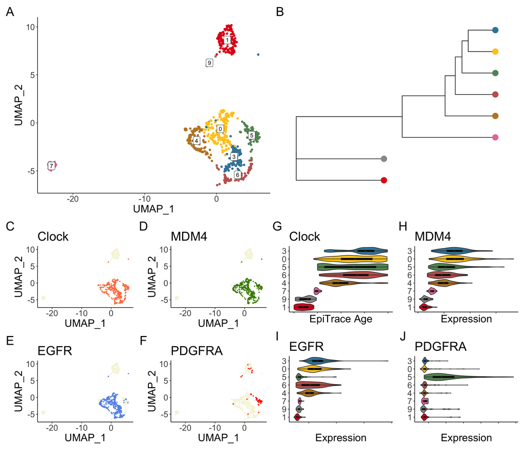

```r
(
(p1|p2_tree+theme(legend.position = 'none')+theme(text = element_text(size=20)))/
    (wrap_plots(final_gene_exp_umap_list,ncol=2) | wrap_plots(final_gene_exp_violin_list,ncol=2))
) + plot_layout(tag_level = 'new') + plot_annotation(tag_levels = 'A')
```

```r
NA
NA
```

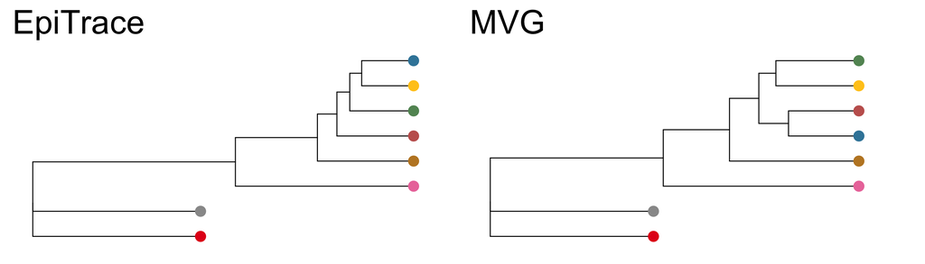

```r
(
(p2_tree + ggtitle('EpiTrace') + theme(text=element_text(size=30)))| (p_tree_mvg + ggtitle('MVG')+ theme(text=element_text(size=30)))
)
```

# test the origin of EGFR+, MDM4+, PDGFRA+ clones

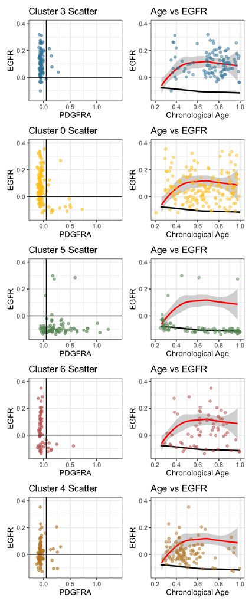

```r
#
# ggplot(epitrace_obj_age_estimated@meta.data[epitrace_obj_age_estimated@meta.data$seurat_clusters%in%c(4,5,6,0,3),],aes(x=PDGFRA,y=EGFR)) + geom_point(aes(color=seurat_clusters)) + scale_color_manual(values = colors_plot) + theme_bw()  + facet_wrap(~seurat_clusters) + geom_hline(yintercept = 0) + geom_vline(xintercept = 0.01)
#
# ggplot(epitrace_obj_age_estimated@meta.data[epitrace_obj_age_estimated@meta.data$seurat_clusters%in%c(4,5,6,0,3),],aes(x=EpiTraceAge_ChronologyClock,y=EGFR)) + geom_point(aes(color=seurat_clusters)) + scale_color_manual(values = colors_plot) + theme_bw()  + facet_wrap(~seurat_clusters)


lapply(c(3,0,5,6,4),function(clusterid){
  ggplot(epitrace_obj_age_estimated@meta.data[epitrace_obj_age_estimated@meta.data$seurat_clusters%in%clusterid,],aes(x=PDGFRA,y=EGFR)) + geom_point(aes(color=seurat_clusters),alpha=0.6) + scale_color_manual(values = colors_plot) + theme_bw() + theme(legend.position = 'none') + ggtitle(paste0('Cluster ',clusterid, ' Scatter')) + xlim(c(-0.2,1.4)) + ylim(c(-0.15,0.4)) + geom_hline(yintercept = 0) + geom_vline(xintercept = 0.05) -> p1
  ggplot(epitrace_obj_age_estimated@meta.data[epitrace_obj_age_estimated@meta.data$seurat_clusters%in% clusterid,],aes(x=EpiTraceAge_AllClock,y=EGFR))  + scale_color_manual(values = colors_plot) + theme_bw()  + geom_smooth(data=epitrace_obj_age_estimated@meta.data[epitrace_obj_age_estimated@meta.data$seurat_clusters%in%c(5,6) & epitrace_obj_age_estimated@meta.data$EGFR>= -0.08,],mapping=aes(),color='red')  + geom_smooth(data=epitrace_obj_age_estimated@meta.data[epitrace_obj_age_estimated@meta.data$seurat_clusters%in%c(5,6) & epitrace_obj_age_estimated@meta.data$EGFR <= -0.05,],mapping=aes(),color='black') + geom_point(alpha=0.5,aes(color=seurat_clusters)) + ylim(c(-0.15,0.4)) + xlim(c(0.2,1)) + theme(legend.position = 'none') + ggtitle(paste0('Age vs EGFR')) + xlab('Chronological Age')  -> p2
  return(wrap_plots(list(p1,p2),nrow=1))
}) -> t1

t1 %>% wrap_plots(nrow=5)
```

#### Insert pie charts to show the evolutionarily relationship

```r
library(ggtree)
library(reshape2)
library(ggplot2)
library(magick)
library(treeio)

p <- p2_tree

p$data %>% dplyr::select(node,label) -> node_label_df

epitrace_obj_age_estimated@meta.data -> prepare_data_meta
prepare_data_meta$label <- prepare_data_meta$seurat_clusters
prepare_data_meta %>% dplyr::group_by(label) %>% dplyr::summarise(Normal=sum(EpiTraceAge_MitosisClock<0.3),MDM4_amp=sum(MDM4>-0.1),EGFR=sum(EGFR>0 ),PDGFRA=sum(PDGFRA>0.05),n=n())
```

| label | Normal | MDM4_amp | EGFR | PDGFRA | n |
| --- | --- | --- | --- | --- | --- |
| 1 | 133 | 8 | 0 | 8 | 138 |
| 9 | 19 | 2 | 0 | 3 | 20 |
| 7 | 36 | 26 | 0 | 0 | 39 |
| 4 | 4 | 96 | 58 | 8 | 104 |
| 6 | 12 | 58 | 39 | 7 | 66 |
| 5 | 8 | 83 | 5 | 66 | 85 |
| 0 | 6 | 170 | 125 | 16 | 172 |
| 3 | 2 | 108 | 99 | 4 | 108 |

```r
prepare_data_meta%>%dplyr::select(EpiTraceAge_MitosisClock,MDM4,PDGFRA,EGFR) %>% dist %>% hclust() %>% cutree(5) -> prepare_data_meta$hdist_class
table(prepare_data_meta$hdist_class,prepare_data_meta$seurat_clusters)
```

```
      1   9   7   4   6   5   0   3
  1 137  20  38   8  10  10   5   1
  2   1   0   1  94  53  34 157 105
  3   0   0   0   2   3  34  10   1
  4   0   0   0   0   0   7   0   0
  5   0   0   0   0   0   0   0   1
```

```r
prepare_data_meta %>% dplyr::group_by(hdist_class) %>% dplyr::summarise(age=mean(EpiTraceAge_MitosisClock,na.rm=T),EGFR=mean(EGFR),PDGFRA=mean(PDGFRA),MDM4=mean(MDM4))
```

| hdist_class | age | EGFR | PDGFRA | MDM4 |
| --- | --- | --- | --- | --- |
| 1 | 0.1588898 | -0.10208159 | -0.02948256 | -0.11276969 |
| 2 | 0.6644738 | 0.05936763 | -0.03579002 | 0.05834682 |
| 3 | 0.5816416 | -0.08230265 | 0.33752791 | 0.01701263 |
| 4 | 0.6443228 | -0.09901934 | 0.93166149 | 0.01772304 |
| 5 | 0.3310534 | 0.86105465 | -0.04545443 | 0.17449069 |

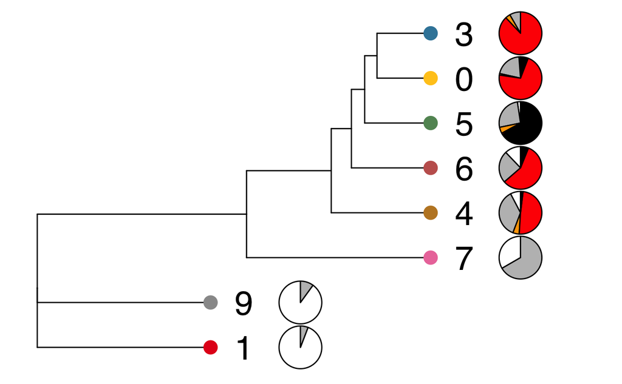

```r
prepare_data_meta$manual_class <- 'Normal'
prepare_data_meta$manual_class[prepare_data_meta$MDM4 > -0.1] <- 'MDM4+'
prepare_data_meta$manual_class[prepare_data_meta$EGFR > 0 & prepare_data_meta$MDM4 > -0.1] <- 'EGFR+'
prepare_data_meta$manual_class[prepare_data_meta$PDGFRA > 0.1 & prepare_data_meta$MDM4 > -0.1] <- 'PDGFRA+'
prepare_data_meta$manual_class[prepare_data_meta$PDGFRA > 0.1 & prepare_data_meta$EGFR > 0 & prepare_data_meta$MDM4 > -0.1] <- 'EGFR+ PDGFRA+'

prepare_data_meta$manual_class <- factor(prepare_data_meta$manual_class,levels=c('Normal','MDM4+','EGFR+ PDGFRA+','EGFR+','PDGFRA+'))

left_join(prepare_data_meta%>%dplyr::group_by(seurat_clusters) %>% dplyr::summarise(n_class=n()),prepare_data_meta%>%dplyr::group_by(manual_class,seurat_clusters) %>% dplyr::summarise(n_sub_class=n())) -> df1
df1$freq <- df1$n_sub_class/df1$n_class
df1$label <- df1$seurat_clusters


colors_pie = c('Normal'='white','MDM4+'='gray','EGFR+ PDGFRA+'='orange','EGFR+'='red','PDGFRA+'='black')

## create list to hold all pie charts
pies = list()
for (i in c(na.omit(p$data)$node) ) {
  ## create a ggplot object for each pie chart
  labelid <- p$data$label[p$data$node%in%i] %>% unique()
  pies[[i]] =  ggplot(df1[df1$label %in% labelid,], aes(y = freq, fill = manual_class, x="")) +
    geom_bar(stat = "identity",color='black',size=0.5) +
    coord_polar("y", start=0) +
    theme_void() + scale_fill_manual(values=colors_pie) + theme(legend.position='none')
}
# give them the appropriate names and plot on tree
names(pies) = c(na.omit(p$data)$node)
p+geom_inset(pies,x='node',width=0.17, height=0.17,hjust = -40) + xlim(c(NA,p$data$x%>%max(na.rm=T)*1.4))
```

```r
prepare_data_meta %>% dplyr::group_by(seurat_clusters,manual_class) %>% dplyr::summarise(meanAge=mean(EpiTraceAge_MitosisClock))
```

| seurat_clusters | manual_class | meanAge |
| --- | --- | --- |
| 1 | Normal | 0.1378933 |
| 1 | MDM4+ | 0.1980164 |
| 9 | Normal | 0.1595987 |
| 9 | MDM4+ | 0.2441860 |
| 7 | Normal | 0.1761549 |
| 7 | MDM4+ | 0.1756287 |
| 4 | Normal | 0.6511628 |
| 4 | MDM4+ | 0.6046512 |
| 4 | EGFR+ PDGFRA+ | 0.5346101 |
| 4 | EGFR+ | 0.5589174 |

[output cut: 18 more lines]

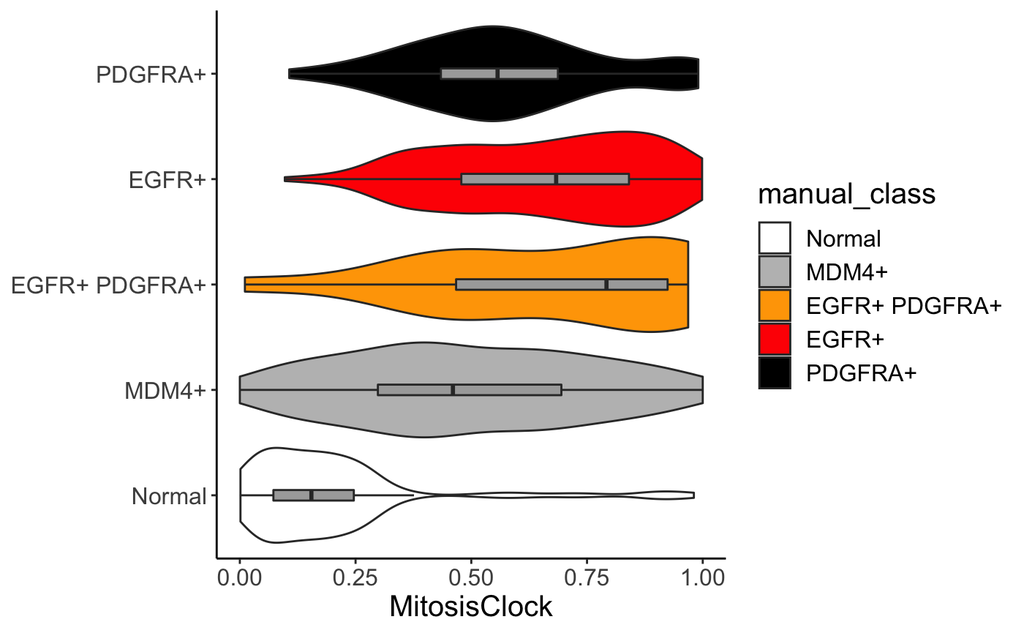

```r
ggplot(prepare_data_meta,aes(x=EpiTraceAge_MitosisClock,y=manual_class)) + geom_violin(aes(fill=manual_class),scale='width') + theme_classic() + geom_boxplot(fill='darkgray',outlier.alpha = 0,width=0.1) + scale_fill_manual(values=colors_pie) + theme(axis.title.y = element_blank(),text=element_text(size=15)) + xlab('MitosisClock')
```